# London Fire

Annarath

This report is one of my assignments for the module Business Statistics at the Warwick Business School.

# Section 1

This report fulfills the requests from Fire service managers and local politicians, performing the specific analyses requested.

1. Provide a breakdown for the sum of all costs associated with responding to fires during the time period, and (separately) the sum of all costs associated with responding to false alarms. Also, the average (mean) cost of responding to a fire, and of responding to a false alarm.
2. Provide a visualisation showing response times to all incidents where there was indeed a response.
3. Provide summary statistics for response times in the special service incidences.
4. Perform a two sample t-test to see if there is a significant difference in the average response times for Ealing area compared to those in Greenwich.
5. Perform a Estimation approach and assess the confidence interval.

# Import Libraries

```r
library(dplyr)
library(tidyverse)
library(Rmisc)
library(emmeans)
library(gridExtra)
library(kableExtra)
options(width=100)
```

## Read Data

```r
#Import London Fire data set as fire_data
fire_data <- read_csv('London_Fire_data (2).csv')
```

## Data Dictionary

This Data Dictionary includes only variables that are used in this analysis. This description is referred from the Fire service.

[output not shown]

## Data Structure and Summary

```r
#Check Data Structure
str(fire_data)
```

```
## spec_tbl_df [322,375 × 39] (S3: spec_tbl_df/tbl_df/tbl/data.frame)
##  $ IncidentNumber                        : chr [1:322375] "000006-01012019" "000019-01012019" "000020-01012019" "000021-01012019" ...
##  $ DateOfCall                            : chr [1:322375] "01-Jan-19" "01-Jan-19" "01-Jan-19" "01-Jan-19" ...
##  $ CalYear                               : num [1:322375] 2019 2019 2019 2019 2019 ...
##  $ TimeOfCall                            : 'hms' num [1:322375] 00:01:45 00:04:33 00:04:39 00:04:44 ...
##   ..- attr(*, "units")= chr "secs"
##  $ HourOfCall                            : num [1:322375] 0 0 0 0 0 0 0 0 0 0 ...
##  $ IncidentGroup                         : chr [1:322375] "Special Service" "Fire" "False Alarm" "False Alarm" ...
##  $ StopCodeDescription                   : chr [1:322375] "Special Service" "Secondary Fire" "False alarm - Good intent" "AFA" ...
##  $ SpecialServiceType                    : chr [1:322375] "Lift Release" NA NA NA ...
##  $ PropertyCategory                      : chr [1:322375] "Dwelling" "Outdoor" "Outdoor" "Dwelling" ...
##  $ PropertyType                          : chr [1:322375] "Purpose Built Flats/Maisonettes - 4 to 9 storeys" "Tree scrub" "Domestic garden (vegetation not equipment)" "Stately Home (part not open to public)" ...
##  $ AddressQualifier                      : chr [1:322375] "Correct incident location" "On land associated with building" "In street outside gazetteer location" "Within same building" ...
##  $ Postcode_full                         : chr [1:322375] NA "N9 7HU" "N20 0BB" NA ...
##  $ Postcode_district                     : chr [1:322375] "SE11" "N9" "N20" "SW7" ...
##  $ UPRN                                  : num [1:322375] 0.00 2.07e+08 2.00e+08 0.00 0.00 ...
##  $ USRN                                  : num [1:322375] 21901674 20704497 20037660 8400731 22700484 ...
##  $ IncGeo_BoroughCode                    : chr [1:322375] "E09000022" "E09000010" "E09000003" "E09000033" ...
##  $ IncGeo_BoroughName                    : chr [1:322375] "LAMBETH" "ENFIELD" "BARNET" "WESTMINSTER" ...
##  $ ProperCase                            : chr [1:322375] "Lambeth" "Enfield" "Barnet" "Westminster" ...
##  $ IncGeo_WardCode                       : chr [1:322375] "E05000427" "E05000204" "E05000043" "E05000637" ...
##  $ IncGeo_WardName                       : chr [1:322375] "PRINCE'S" "LOWER EDMONTON" "BRUNSWICK PARK" "KNIGHTSBRIDGE AND BELGRAVIA" ...
##  $ IncGeo_WardNameNew                    : chr [1:322375] "PRINCE'S" "LOWER EDMONTON" "BRUNSWICK PARK" "KNIGHTSBRIDGE AND BELGRAVIA" ...
##  $ Easting_m                             : num [1:322375] NA 534494 527630 NA NA ...
##  $ Northing_m                            : num [1:322375] NA 194099 193922 NA NA ...
##  $ Easting_rounded                       : num [1:322375] 530850 534450 527650 526750 537250 ...
##  $ Northing_rounded                      : num [1:322375] 178650 194050 193950 179550 183250 ...
##  $ Latitude                              : num [1:322375] NA 51.6 51.6 NA NA ...
##  $ Longitude                             : num [1:322375] NA -0.0582 -0.1574 NA NA ...
##  $ FRS                                   : chr [1:322375] "London" "London" "London" "London" ...
##  $ IncidentStationGround                 : chr [1:322375] "Lambeth" "Edmonton" "Barnet" "Kensington" ...
##  $ FirstPumpArriving_AttendanceTime      : num [1:322375] NA 357 318 210 329 422 180 335 369 268 ...
##  $ FirstPumpArriving_DeployedFromStation : chr [1:322375] NA "Edmonton" "Southgate" "Kensington" ...
##  $ SecondPumpArriving_AttendanceTime     : num [1:322375] NA NA NA NA NA 520 NA NA 486 NA ...
##  $ SecondPumpArriving_DeployedFromStation: chr [1:322375] NA NA NA NA ...
##  $ NumStationsWithPumpsAttending         : num [1:322375] 1 1 1 1 1 2 1 1 2 1 ...
##  $ NumPumpsAttending                     : num [1:322375] 1 1 1 1 1 2 1 1 2 1 ...
##  $ PumpCount                             : num [1:322375] 1 1 1 1 1 2 1 1 4 1 ...
##  $ PumpHoursRoundUp                      : num [1:322375] 1 1 1 1 1 3 1 1 4 1 ...
##  $ Notional Cost (£)                     : num [1:322375] 333 333 333 333 333 ...
```

[output cut: 29 more lines]

```
##   ..   Longitude = col_double(),
##   ..   FRS = col_character(),
##   ..   IncidentStationGround = col_character(),
##   ..   FirstPumpArriving_AttendanceTime = col_double(),
##   ..   FirstPumpArriving_DeployedFromStation = col_character(),
##   ..   SecondPumpArriving_AttendanceTime = col_double(),
##   ..   SecondPumpArriving_DeployedFromStation = col_character(),
##   ..   NumStationsWithPumpsAttending = col_double(),
##   ..   NumPumpsAttending = col_double(),
##   ..   PumpCount = col_double(),
##   ..   PumpHoursRoundUp = col_double(),
##   ..   `Notional Cost (£)` = col_double(),
##   ..   NumCalls = col_double()
##   .. )
##  - attr(*, "problems")=<externalptr>
```

```r
#Check Data Summary
summary(fire_data)
```

```
##  IncidentNumber      DateOfCall           CalYear      TimeOfCall         HourOfCall
##  Length:322375      Length:322375      Min.   :2019   Length:322375     Min.   : 0.00
##  Class :character   Class :character   1st Qu.:2019   Class1:hms        1st Qu.: 9.00
##  Mode  :character   Mode  :character   Median :2020   Class2:difftime   Median :14.00
##                                        Mean   :2020   Mode  :numeric    Mean   :13.42
##                                        3rd Qu.:2021                     3rd Qu.:19.00
##                                        Max.   :2022                     Max.   :23.00
##
##  IncidentGroup      StopCodeDescription SpecialServiceType PropertyCategory   PropertyType
##  Length:322375      Length:322375       Length:322375      Length:322375      Length:322375
##  Class :character   Class :character    Class :character   Class :character   Class :character
##  Mode  :character   Mode  :character    Mode  :character   Mode  :character   Mode  :character
##
##
##
##
##  AddressQualifier   Postcode_full      Postcode_district       UPRN                USRN
##  Length:322375      Length:322375      Length:322375      Min.   :0.000e+00   Min.   : 4200740
##  Class :character   Class :character   Class :character   1st Qu.:0.000e+00   1st Qu.:20400989
##  Mode  :character   Mode  :character   Mode  :character   Median :0.000e+00   Median :21201121
##                                                           Mean   :2.072e+10   Mean   :20400837
##                                                           3rd Qu.:1.001e+10   3rd Qu.:22100813
##                                                           Max.   :2.000e+11   Max.   :99990422
##
##  IncGeo_BoroughCode IncGeo_BoroughName  ProperCase        IncGeo_WardCode    IncGeo_WardName
##  Length:322375      Length:322375      Length:322375      Length:322375      Length:322375
##  Class :character   Class :character   Class :character   Class :character   Class :character
##  Mode  :character   Mode  :character   Mode  :character   Mode  :character   Mode  :character
##
##
##
##
##  IncGeo_WardNameNew   Easting_m        Northing_m     Easting_rounded  Northing_rounded
##  Length:322375      Min.   :503582   Min.   :155998   Min.   :503550   Min.   :155950
##  Class :character   1st Qu.:524924   1st Qu.:175804   1st Qu.:525150   1st Qu.:176050
##  Mode  :character   Median :530858   Median :180978   Median :530950   Median :181050
##                     Mean   :530634   Mean   :180340   Mean   :530667   Mean   :180487
##                     3rd Qu.:537035   3rd Qu.:185076   3rd Qu.:536350   3rd Qu.:185250
##                     Max.   :560461   Max.   :200885   Max.   :611150   Max.   :302450
##                     NA's   :175667   NA's   :175667
```

[output cut: 25 more lines]

```
##  Min.   : 1.0                  Min.   : 1.000    Min.   :  1.000   Min.   :   1.00
##  1st Qu.: 1.0                  1st Qu.: 1.000    1st Qu.:  1.000   1st Qu.:   1.00
##  Median : 1.0                  Median : 1.000    Median :  1.000   Median :   1.00
##  Mean   : 1.4                  Mean   : 1.571    Mean   :  1.619   Mean   :   1.37
##  3rd Qu.: 2.0                  3rd Qu.: 2.000    3rd Qu.:  2.000   3rd Qu.:   1.00
##  Max.   :14.0                  Max.   :14.000    Max.   :250.000   Max.   :1203.00
##  NA's   :3823                  NA's   :3823      NA's   :2008      NA's   :2111
##  Notional Cost (£)     NumCalls
##  Min.   :   333.0   Min.   :  1.000
##  1st Qu.:   339.0   1st Qu.:  1.000
##  Median :   346.0   Median :  1.000
##  Mean   :   471.9   Mean   :  1.306
##  3rd Qu.:   352.0   3rd Qu.:  1.000
##  Max.   :407817.0   Max.   :175.000
##  NA's   :2111       NA's   :4
```

## 1. Cost Responding to Fires and False Alarms

The sum and average of all costs associated with responding to fires and false alarms during the time period.

```r
sum(is.na(fire_data$`Notional Cost (£)`))
```

```
## [1] 2111
```

```r
#There are only 2111 out of 322375 entries that contains NA for the Notional Costs variable. Hence, it would not effect the average value significantly if we omit NA. (Do not need to fill NA)
```

```r
summary_cost <- fire_data %>%
    group_by(IncidentGroup) %>%
    dplyr::summarise(
        count_incident=n(),
        sum_all_cost = sum(`Notional Cost (£)`, na.rm = TRUE),
        average_all_cost = sum_all_cost/count_incident)

summary_cost
```

```
## # A tibble: 3 × 4
##   IncidentGroup   count_incident sum_all_cost average_all_cost
##   <chr>                    <int>        <dbl>            <dbl>
## 1 False Alarm             162299     61249812             377.
## 2 Fire                     51443     43059576             837.
## 3 Special Service         108633     46812402             431.
```

## 2. The distribution of response times

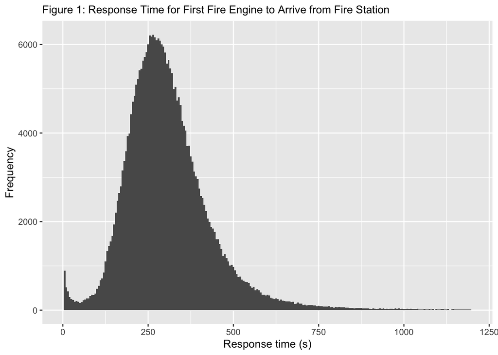

```r
ggplot(fire_data, aes(x=FirstPumpArriving_AttendanceTime)) +
    geom_histogram(binwidth=5) +
    xlim(0, 1200) +
    labs(x="Response time (s)",
         y="Frequency",
         subtitle="Figure 1: Response Time for First Fire Engine to Arrive from Fire Station")
```

```r
#ggsave("figure1.png")

#Response times of all incidents
```

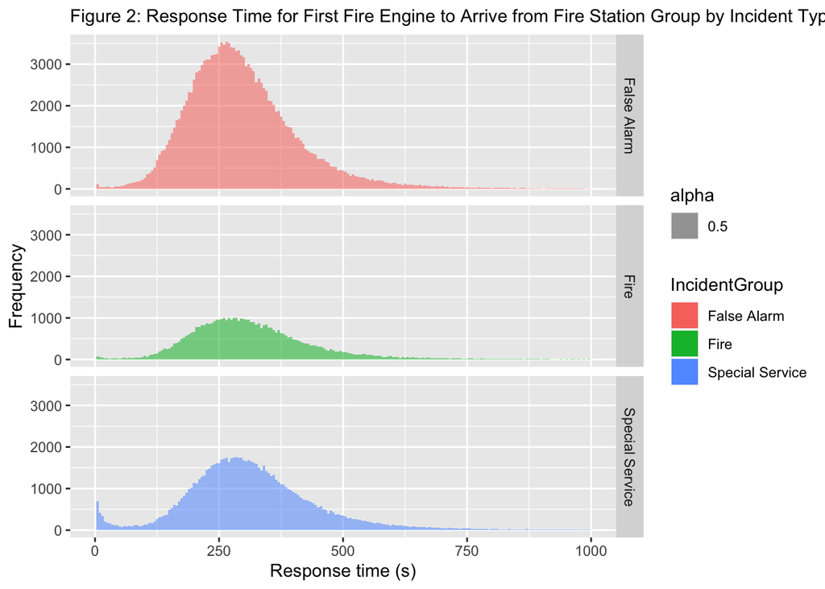

```r
type_time <- fire_data %>% group_by("IncidentGroup")%>%  summarise(type_mean=mean(FirstPumpArriving_AttendanceTime))

ggplot(fire_data, aes(x=FirstPumpArriving_AttendanceTime, fill=IncidentGroup, alpha=0.5)) +
    geom_histogram(binwidth=5) +
    facet_grid(IncidentGroup~.)+
    geom_vline(data=type_time, aes(xintercept=type_mean), linetype=2, colour='black', size=0.4) +
    xlim(0,1000) +
    labs(x="Response time (s)",
         y="Frequency",
         subtitle="Figure 2: Response Time for First Fire Engine to Arrive from Fire Station Group by Incident Type")
```

```r
#ggsave("figure2.png")

#Figure 2 shows the response times of the three different types of incident (“Fire”, “False Alarm” and “Special Service”) where there was indeed a response.

#For the easier comparison of the distribution of data.

#All group's outliers are within the same range which is about > 900.

#I will be working with outliers in the next chunk to increase the accuracy in further calculations with First Pimp Response time.
```

```r
#Omit Outliers
fire_data <- filter(fire_data, FirstPumpArriving_AttendanceTime < 900)
```

## 3. Summary of Special Service Response Times

Summary of counts and mean of each type of incident and 10th and 90th percentile of response times for each types of incident in ‘Special Service’ Incident Group.

```r
special_type <- fire_data %>% filter(IncidentGroup == 'Special Service') %>% group_by(SpecialServiceType) %>% drop_na() %>% dplyr::summarise(count=n(), tenth_percentiles=quantile(FirstPumpArriving_AttendanceTime, probs = 0.1, na.rm=TRUE), mean_response_time=mean(FirstPumpArriving_AttendanceTime, na.rm=TRUE), ninetieth_percentiles=quantile(FirstPumpArriving_AttendanceTime, probs = 0.9, na.rm=TRUE))

special_type
```

```
## # A tibble: 19 × 5
##    SpecialServiceType              count tenth_percentiles mean_response_time ninetieth_percentiles
##    <chr>                           <int>             <dbl>              <dbl>                 <dbl>
##  1 Advice Only                        42             193.                313.                  430.
##  2 Animal assistance incidents        15              90.2               311.                  469.
##  3 Assist other agencies             224             178.                310.                  475.
##  4 Effecting entry/exit               43             111.                293.                  449
##  5 Evacuation (no fire)               23             147.                351.                  600
##  6 Flooding                           83             129.                314.                  648.
##  7 Hazardous Materials incident      367             185.                297.                  427.
##  8 Lift Release                        9              80.2               193.                  280
##  9 Making Safe (not RTC)             111             152                 279.                  422
## 10 Medical Incident                  121              40                 260.                  402
## 11 No action (not false alarm)       494             188                 323.                  474
## 12 Other rescue/release of persons   169             180.                305.                  452.
## 13 Other Transport incident          242             156                 294.                  452
## 14 Removal of objects from people     54             177.                304.                  419
## 15 Rescue or evacuation from water   133             175.                306.                  442.
## 16 RTC                              5180             177                 316.                  480
## 17 Spills and Leaks (not RTC)         77             176.                334.                  475.
## 18 Stand By                           64             160.                290.                  433.
## 19 Suicide/attempts                  181             145                 283.                  430
```